# PCA

2023-05-04

## 1. Load packages

```r
library(tidyverse)
library(DESeq2)
library(ggrepel)
```

## 2. Data transformation

##### **2.a. Import data sets**

The following data sets are provided by Dr. Rebecca L. Young.

```r
frog_raw_counts_greaterthan5 <- read.table(file = "/stor/work/Bio321G_RY_Spring2023/MiniProjects/PoisonFrogLivers/genecounts.greaterthan5.raw.csv",
                                           row.names = 1,
                                           header = TRUE,
                                           sep = ",")

frog_metadata <- read.delim(file = "/stor/work/Bio321G_RY_Spring2023/MiniProjects/PoisonFrogLivers/Metadata_EpipedobatesTranscriptomeProject2021.txt")
```

##### **2.b. Normalization**

Since the gene length is not provided, we will use DeSeq2 to normalize our raw counts

```r
dds <- DESeqDataSetFromMatrix(countData=frog_raw_counts_greaterthan5, design = ~condition,
                              colData=frog_metadata)

dds <- estimateSizeFactors(dds)

normalized_counts_greater_5 <- counts(dds, normalized = TRUE)
```

## 3. Principal Component Analysis (PCA)

PCA is a dimensionality reduction method which reduces the number of dimensions of multi-dimensional data sets, which helps us to visualize and interpret the data much better. While reducing the dimension, PCA still preserves the amount of information, allowing a comprehensive overview of the data set.

##### **3.a. Calculate the PCs**

```r
x <- normalized_counts_greater_5 %>%
  t()   # Transpose the matrix

PC_x <- prcomp(x)   # Calculate the PCs

PCs_x <- data.frame(PC_x$x) %>%
  rownames_to_column(var = "sample_id")

head(PCs_x, 10)
```

```
##      sample_id       PC1         PC2         PC3        PC4         PC5
## 1   A1.6854_S1 -39562.41   -342.5773  -9404.7575 -2073.1319   3305.1680
## 2  A3.6830_S17  21909.17  27432.2706  -8311.4987 -1777.0711 -11904.6700
## 3   B1.6855_S2  71864.29  10319.9164   1552.8794  1712.2488   2081.8945
## 4  B2.6813_S10  18565.00 -13279.3162   6328.9341 -1895.6037  -2819.1610
## 5  B3.6832_S18   7140.44 -14883.7208  -5635.1653  3048.1746    274.9454
## 6   C1.6872_S3 -18569.83   -296.5142  -5994.8365 -1842.0134   3851.0146
## 7  C2.6821_S11 -23194.78 -22919.1079    221.8982  7814.0353  -4806.9118
## 8  C3.6835_S19 -13121.78  -1836.0159 -10054.3150  -231.2435   1617.8117
## 9   D1.6863_S4  81802.01   5185.5556   4677.7633  -193.3651   2021.8303
## 10 D2.6822_S12  69158.21  11080.2149   4600.0748  3547.2010    998.4706
##           PC6        PC7         PC8        PC9       PC10        PC11
## 1   3536.1971 -3685.3603 -1874.67620  262.12854  -771.0563  1593.94782
## 2  -2022.9889 -1031.0081  -111.07274  116.52500  -157.5630   -18.53249
## 3   1823.5021  -426.0612   133.64454  718.78058 -1328.5323   292.11726
```

[output cut: 29 more lines]

##### **3.b. Scree plot**

A common method for determining the number of PCs to be retained is a graphical representation known as a scree plot.

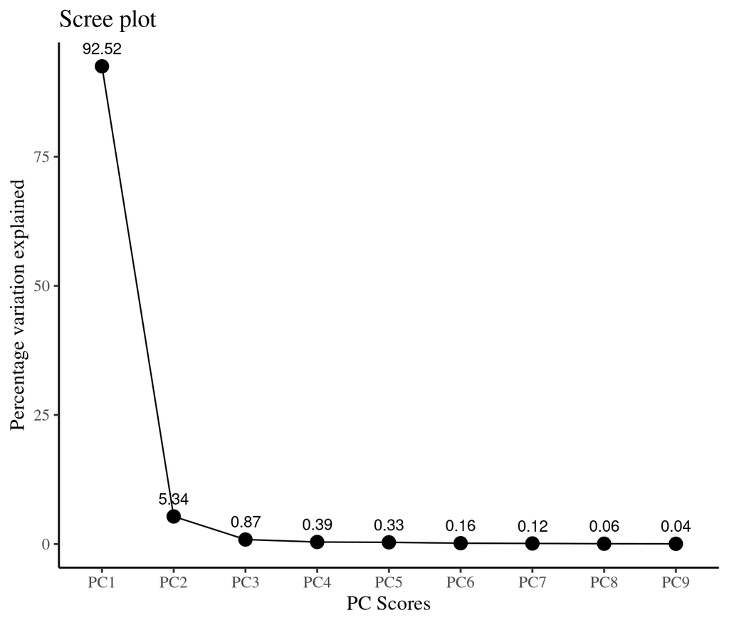

```r
# Calculate the variation explained by each PCs
var_explained <- data.frame(PC = paste0("PC", 1:ncol(PC_x$x)),
                            var_explained=(PC_x$sdev)^2/sum((PC_x$sdev)^2))

PC1to9_Var <- var_explained[1:9,]

ggplot(PC1to9_Var, aes(x= PC,y = var_explained * 100, group = 1)) +
  geom_point(size=4) +
  geom_line() +
  geom_text(aes(label = round(var_explained, 4)*100, vjust = -1)) +
  labs(title = "Scree plot", y = "Percentage variation explained", x = "PC Scores") +
  theme_classic(base_family = "Times",
                base_size = 14)
```

## 4. Visualization - PCAs

Now, let”s plot PCA for PC1 and PC2

##### **4.a. Check for anomalies**

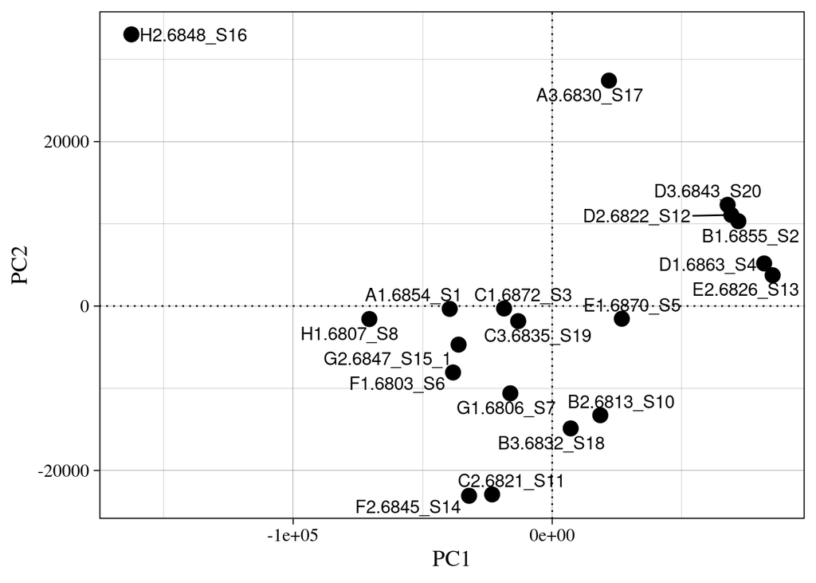

```r
ggplot(data = PCs_x, aes(x = PC1, y = PC2)) +
  geom_point(size = 4) +
  geom_text_repel(aes(x = PC1, y = PC2, label = sample_id)) +
  geom_hline(yintercept = 0, linetype = "dotted") +
  geom_vline(xintercept = 0, linetype = "dotted") +
  theme_linedraw(base_family = "Times",
                 base_size = 14)
```

This might look daunting at first, but the purpose is to identify the anomalies, which are the two samples `H2.6848_S16` and `A3.6830_S17`.

```r
# Remove rows containing the two anomalies
PCs_x <- PCs_x %>%
  subset(sample_id != c("H2.6848_S16", "A3.6830_S17"))
```

##### **4.b. Plot by species**

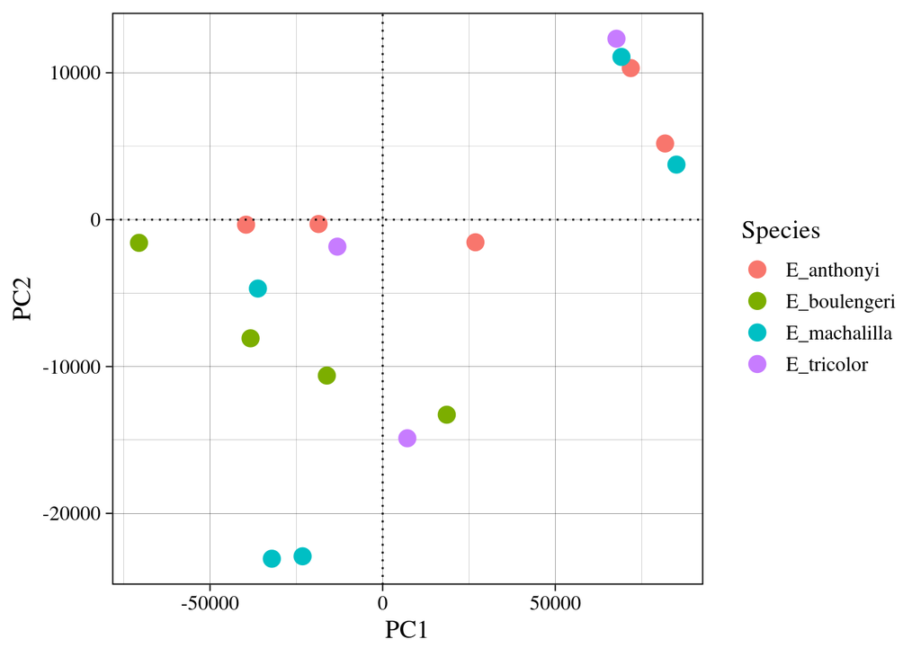

```r
# Add another column which provides the species related to each gene
PCs_x <- PCs_x %>%
  mutate(Species = case_when(
    sample_id == "A1.6854_S1" ~ "E_anthonyi",
    sample_id == "B1.6855_S2"~ "E_anthonyi",
    sample_id == "C1.6872_S3" ~ "E_anthonyi",
    sample_id ==  "D1.6863_S4"~ "E_anthonyi",
    sample_id == "E1.6870_S5"~ "E_anthonyi",
    sample_id == "F1.6803_S6" ~ "E_boulengeri",
    sample_id == "G1.6806_S7" ~ "E_boulengeri",
    sample_id == "H1.6807_S8"~ "E_boulengeri",
    sample_id == "B2.6813_S10" ~ "E_boulengeri",
    sample_id ==  "C2.6821_S11"~ "E_machalilla",
    sample_id == "D2.6822_S12"~ "E_machalilla",
    sample_id == "E2.6826_S13" ~ "E_machalilla",
    sample_id == "F2.6845_S14" ~ "E_machalilla",
    sample_id == "G2.6847_S15_1" ~ "E_machalilla",
    sample_id == "H2.6848_S16" ~ "E_machalilla",
    TRUE ~ "E_tricolor"))   # The remaining ones are E_tricolor


# Plot
ggplot(data = PCs_x, aes(x = PC1, y = PC2, color = Species)) +
  geom_point(size = 4) +
  geom_hline(yintercept = 0, linetype = "dotted") +
  geom_vline(xintercept = 0, linetype = "dotted") +
  theme_linedraw(base_family = "Times",
                 base_size = 14)
```

We can see that there”s no clear pattern/cluster.

##### **4.c. Plot by skin coloration**

Let”s try a different approach by cateogorizing the points by cryptic/aposematic

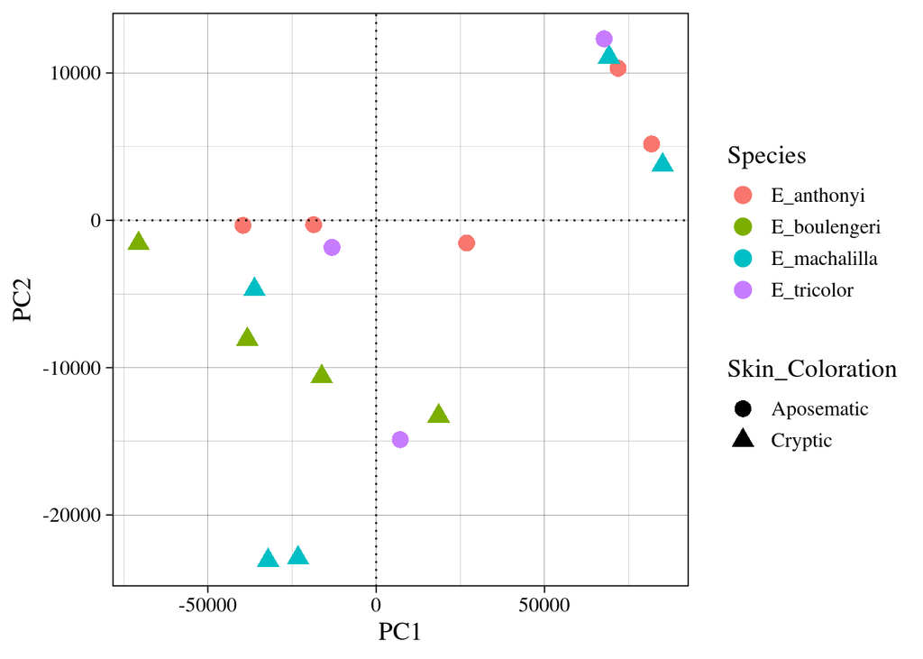

```r
# Add another column which provides the skin coloration related to each species
PCs_x <- PCs_x %>%
  mutate(Skin_Coloration = case_when(
    Species == "E_anthonyi" ~ "Aposematic",
    Species == "E_tricolor" ~ "Aposematic",
    Species == "E_machalilla" ~ "Cryptic",
    Species == "E_boulengeri" ~ "Cryptic"))

# Plot
ggplot(data = PCs_x, aes(x = PC1, y = PC2, shape = Skin_Coloration, color = Species)) +
  geom_point(size = 4) +
  geom_hline(yintercept = 0, linetype = "dotted") +
  geom_vline(xintercept = 0, linetype = "dotted") +
  theme_linedraw(base_family = "Times",
                 base_size = 14)
```

Again, we can see that there”s no clear pattern/cluster.

##### **4.d. Plot by localities**

Another potential approach could be categorizing the points by where the samples of Epipedobates were collected. The information regarding the localities is provided by Dr. Rebecca L. Young.

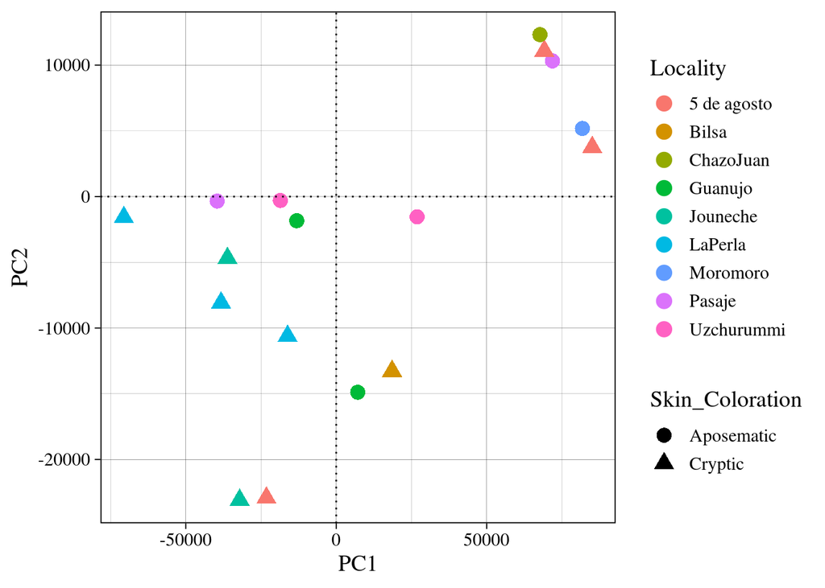

```r
# Add another column which provides the localities at which the Epipedobates were collected
PCs_x <- PCs_x %>%
  mutate(Locality = case_when(
    sample_id == "A1.6854_S1" ~ "Pasaje", sample_id == "B1.6855_S2" ~ "Pasaje",
    sample_id == "C1.6872_S3" ~ "Uzchurummi", sample_id ==  "D1.6863_S4" ~ "Moromoro",
    sample_id == "E1.6870_S5" ~ "Uzchurummi", sample_id == "F1.6803_S6" ~ "LaPerla",
    sample_id == "G1.6806_S7" ~ "LaPerla", sample_id == "H1.6807_S8" ~ "LaPerla",
    sample_id == "B2.6813_S10" ~ "Bilsa", sample_id ==  "C2.6821_S11"~ "5 de agosto",
    sample_id == "D2.6822_S12" ~ "5 de agosto", sample_id == "E2.6826_S13" ~ "5 de agosto",
    sample_id == "F2.6845_S14" ~ "Jouneche", sample_id == "G2.6847_S15_1" ~ "Jouneche",
    sample_id == "H2.6848_S16" ~ "Jouneche", sample_id == "A3.6830_S17" ~ "Guanujo",
    sample_id == "C3.6835_S19" ~ "Guanujo", sample_id == "B3.6832_S18" ~ "Guanujo",
    sample_id == "D3.6843_S20" ~ "ChazoJuan"))

# Plot
ggplot(data = PCs_x, aes(x = PC1, y = PC2, shape = Skin_Coloration, color = Locality)) +
  geom_point(size = 4) +
  geom_hline(yintercept = 0, linetype = "dotted") +
  geom_vline(xintercept = 0, linetype = "dotted") +
  theme_linedraw(base_family = "Times",
                 base_size = 14)
```

Again, we can see that there”s no clear pattern/cluster.

##### **4.e. Plot by sex**

We can also try plotting the Epipedobates by sex (i.e., males and females)

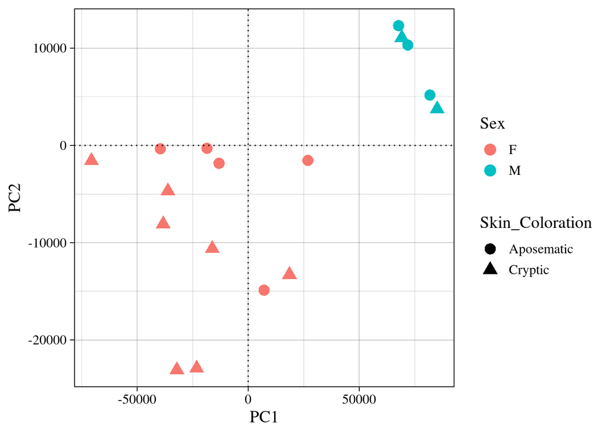

```r
# Add another column which provides the sex of the Epipedobates
PCs_x <- PCs_x %>%
  mutate(Sex = case_when(
    sample_id == "A1.6854_S1" ~ "F", sample_id == "B1.6855_S2"~ "M",
    sample_id == "C1.6872_S3" ~ "F", sample_id ==  "D1.6863_S4"~ "M",
    sample_id == "E1.6870_S5"~ "F", sample_id == "F1.6803_S6" ~ "F",
    sample_id == "G1.6806_S7" ~ "F", sample_id == "H1.6807_S8"~ "F",
    sample_id == "B2.6813_S10" ~ "F", sample_id ==  "C2.6821_S11"~ "F",
    sample_id == "D2.6822_S12"~ "M", sample_id == "E2.6826_S13" ~ "M",
    sample_id == "F2.6845_S14" ~ "F",sample_id == "G2.6847_S15_1" ~ "F",
    sample_id == "H2.6848_S16" ~ "F",sample_id == "A3.6830_S17" ~ "F",
    sample_id == "C3.6835_S19" ~ "F",sample_id == "B3.6832_S18" ~ "F",
    sample_id == "D3.6843_S20" ~ "M"))

# Plot
ggplot(data = PCs_x, aes(x = PC1, y = PC2, shape = Skin_Coloration, color = Sex)) +
  geom_point(size = 4) +
  geom_hline(yintercept = 0, linetype = "dotted") +
  geom_vline(xintercept = 0, linetype = "dotted") +
  theme_linedraw(base_family = "Times",
                 base_size = 14)
```

Here, we can see a clear cluster formed by the males. However, bare in mind that there’s a disproportionate of males (5) compared to females (12) in this plot.

##### **Overall, besides a potential separation due to sex, the PCA displays no separation between Cryptic and Aposematic Epipedobates**